# Introduction

Then create a new dataframe from our dictionary:

```python
songdata = pd.DataFrame.from_dict(songdata_dict, orient='index')
songdata.rename(columns={0: 'Danceability', 1: 'Energy', 2: 'Loudness', 3: 'Speechiness', 4: 'Tempo', 5: 'Time_Signature', 6: 'Valence'}, inplace=True)
songdata
```

|  | Danceability | Energy | Loudness | Speechiness | Tempo | Time_Signature | Valence |
| --- | --- | --- | --- | --- | --- | --- | --- |
| SOMVLMZ136C7995A55 | 0.755807 | 0.842402 | -6.019 | 0.340154 | 94.898 | 4 | 0.677585 |
| SONMCJI13F124CDC19 | 0.815443 | 0.730272 | -10.588 | 0.060452 | 116.057 | 4 | 0.883148 |
| SOJQLXR12A8C141E23 | 0.517948 | 0.659723 | -10.284 | 0.039909 | 177.306 | 4 | 0.894522 |
| SOMBCCL13666718BCC | 0.478584 | 0.546115 | -8.261 | 0.030366 | 141.262 | 4 | 0.336436 |
| SOBCKPM12A6D4FD13C | 0.650690 | 0.720348 | -4.951 | 0.031240 | 129.618 | 4 | 0.911839 |
| SOZYFQB135C3100F43 | 0.286838 | 0.512921 | -7.257 | 0.030029 | 108.261 | 4 | 0.132572 |
| SOTCJZC1315CD4D80E | 0.597979 | 0.703818 | -7.782 | 0.034822 | 168.606 | 4 | 0.698057 |
| SOFLZVQ145E917D0D0 | 0.591964 | 0.318222 | -10.131 | 0.025466 | 102.573 | 3 | 0.539965 |
| SONWYJJ135C2EAF743 | 0.633490 | 0.377734 | -9.526 | 0.026624 | 112.041 | 4 | 0.161429 |
| SOHCCOF144E6681A3C | 0.348962 | 0.448476 | -10.134 | 0.026958 | 84.294 | 3 | 0.374987 |
| SOTITAT144C281345F | 0.776651 | 0.478829 | -14.581 | 0.201306 | 85.700 | 4 | 0.165595 |
| SOHTJBL137673ACA65 | 0.310988 | 0.026383 | -21.644 | 0.037004 | 120.653 | 4 | 0.144008 |
| SOFQYRM1376A29F998 | 0.375093 | 0.339770 | -11.877 | 0.029408 | 99.943 | 4 | 0.228403 |
| SOLXMIB1379E40D862 | 0.568224 | 0.206895 | -19.869 | 0.047560 | 105.037 | 4 | 0.362624 |
| SOTWDOB137382EE526 | 0.660776 | 0.128030 | -19.745 | 0.038306 | 120.438 | 4 | 0.219089 |
| SOXHGGG12AF72A738D | 0.820528 | 0.540598 | -6.750 | 0.050481 | 117.336 | 4 | 0.847722 |
| SOLNZRR144D7F4519F | 0.538118 | 0.588023 | -19.806 | 0.031737 | 127.193 | 4 | 0.752111 |
| SODSVWW13D6673EE0C | 0.265797 | 0.600452 | -5.051 | 0.032541 | 161.208 | 4 | 0.405787 |
| SOENXMC12A8C139E69 | 0.665788 | 0.650905 | -8.459 | 0.025434 | 99.013 | 4 | 0.504165 |
| SOFAIFV1315CD46BCF | 0.531745 | 0.344383 | -10.483 | 0.025644 | 95.974 | 4 | 0.219985 |
| SOZZAZI145FDFBE9D9 | 0.464363 | 0.684871 | -12.744 | 0.048783 | 125.040 | 4 | 0.466776 |
| SOJOFUQ1421603FAEB | 0.344104 | 0.743543 | -9.118 | 0.206271 | 156.040 | 4 | 0.521685 |
| SOHAHIM13C671F1C87 | 0.347428 | 0.695420 | -5.295 | 0.080285 | 183.936 | 4 | 0.715790 |
| SOWGFNX14931A95202 | 0.197368 | 0.240287 | -17.996 | 0.033727 | 100.457 | 3 | 0.376971 |
| SOCIZFF13776833EBB | 0.281551 | 0.178421 | -8.862 | 0.032110 | 129.891 | 5 | 0.069596 |
| SOBRLJQ12A8C13BCA0 | 0.795366 | 0.142090 | -22.653 | 0.049437 | 102.126 | 4 | 0.571902 |
| SOKQKUB144BD5B4173 | 0.482534 | 0.218928 | -15.780 | 0.033161 | 140.527 | 4 | 0.198661 |
| SOXEZLO13D28678C23 | 0.458161 | 0.529160 | -11.153 | 0.031579 | 107.385 | 4 | 0.504310 |
| SOONGGO1498F6BEBB8 | 0.449439 | 0.428370 | -8.415 | 0.043252 | 84.781 | 4 | 0.087876 |
| SOJFQLS13A6A4382C3 | 0.721877 | 0.704613 | -4.054 | 0.049237 | 143.984 | 4 | 0.859276 |
| ... | ... | ... | ... | ... | ... | ... | ... |
| SOKYJEV1449FEA3E6A | 0.194574 | 0.318253 | -12.314 | 0.031522 | 82.668 | 4 | 0.158699 |
| SOEWOTE14373B752F8 | 0.601011 | 0.535039 | -22.214 | 0.050157 | 121.762 | 4 | 0.808284 |
| SODZOAK14788D251F1 | 0.349389 | 0.796963 | -7.339 | 0.059140 | 81.111 | 4 | 0.529597 |
| SOHLDIS139E54A1CB5 | 0.579368 | 0.530245 | -10.095 | 0.040231 | 82.025 | 4 | 0.624810 |
| SOMHELH13E363433C8 | 0.237670 | 0.031188 | -19.567 | 0.036554 | 85.554 | 4 | 0.204739 |
| SOZWZAD141BE397CC8 | 0.367288 | 0.404411 | -10.379 | 0.033196 | 120.067 | 4 | 0.110405 |
| SOSNWTG13E90617E27 | 0.494477 | 0.662635 | -18.027 | 0.050628 | 136.167 | 4 | 0.317310 |
| SODFLND130516E003A | 0.710617 | 0.529574 | -10.348 | 0.031822 | 123.394 | 4 | 0.576028 |
| SOMFSOX1373E9E7D59 | 0.523568 | 0.201303 | -15.875 | 0.029718 | 108.617 | 4 | 0.509327 |
| SOACACD1316771254C | 0.731592 | 0.628601 | -14.866 | 0.046330 | 119.424 | 4 | 0.704238 |
| SOLMHLQ1376EFD5815 | 0.794574 | 0.648229 | -13.544 | 0.029802 | 102.692 | 4 | 0.941418 |
| SOMASMA144AEC76B20 | 0.642160 | 0.524703 | -16.157 | 0.048419 | 91.978 | 4 | 0.804819 |
| SOIFTDQ13FC822A948 | 0.617417 | 0.342823 | -10.814 | 0.029618 | 81.024 | 4 | 0.107008 |
| SOQFQRE13777D00D7E | 0.471596 | 0.683230 | -8.208 | 0.042100 | 189.820 | 4 | 0.653239 |
| SOOUZYZ144A0F2E353 | 0.323690 | 0.472277 | -9.649 | 0.037672 | 113.090 | 4 | 0.295553 |
| SOOGSDU13E90849CDB | 0.426040 | 0.216778 | -16.702 | 0.047156 | 115.645 | 4 | 0.361685 |
| SOFRRST1313438A28D | 0.506771 | 0.452725 | -7.624 | 0.028793 | 123.734 | 4 | 0.175767 |
| SOCWRDZ12AF72A534A | 0.603587 | 0.684757 | -7.829 | 0.026696 | 128.311 | 4 | 0.359829 |
| SOALDKC144B4013A90 | 0.701311 | 0.195621 | -14.881 | 0.072502 | 119.373 | 4 | 0.609508 |
| SOKKALG143E0D38F9C | 0.313788 | 0.434066 | -10.167 | 0.037815 | 78.866 | 4 | 0.464005 |
| SOYSVDM1393C7A7360 | 0.440962 | 0.767882 | -4.078 | 0.073764 | 161.048 | 4 | 0.728136 |
| SOBHQTW13134385C19 | 0.561455 | 0.525043 | -6.012 | 0.033876 | 171.826 | 4 | 0.586327 |
| SOSWKIT13D5E9307EF | 0.391396 | 0.360285 | -13.641 | 0.041360 | 81.712 | 4 | 0.201491 |
| SOBSDDQ13600D7D0A2 | 0.567496 | 0.523961 | -11.320 | 0.029925 | 152.825 | 4 | 0.801407 |
| SOAZHQH1451A2F97CE | 0.680677 | 0.559211 | -7.839 | 0.101372 | 110.453 | 4 | 0.349349 |
| SOTVVAS144ADE2C4FC | 0.804672 | 0.767960 | -5.802 | 0.037194 | 100.342 | 4 | 0.212161 |
| SOLFOXQ141842EB05D | 0.557452 | 0.508895 | -8.612 | 0.030318 | 128.253 | 4 | 0.295443 |
| SOECVUE144BA789B3B | 0.526083 | 0.363837 | -12.607 | 0.028187 | 131.228 | 4 | 0.258560 |
| SOLOVFF144B712BA80 | 0.654723 | 0.950460 | -4.495 | 0.055394 | 98.664 | 4 | 0.898690 |
| SOHDHEA1391229C0EF | 0.468160 | 0.824211 | -13.376 | 0.039042 | 93.051 | 4 | 0.680569 |

285 rows × 7 columns

We can reset our index, as we do not wish to use the song ID for this purpose:

```python
songdata = songdata.reset_index()
songdata.head()
```

|  | index | Danceability | Energy | Loudness | Speechiness | Tempo | Time_Signature | Valence |
| --- | --- | --- | --- | --- | --- | --- | --- | --- |
| 0 | SOMVLMZ136C7995A55 | 0.755807 | 0.842402 | -6.019 | 0.340154 | 94.898 | 4 | 0.677585 |
| 1 | SONMCJI13F124CDC19 | 0.815443 | 0.730272 | -10.588 | 0.060452 | 116.057 | 4 | 0.883148 |
| 2 | SOJQLXR12A8C141E23 | 0.517948 | 0.659723 | -10.284 | 0.039909 | 177.306 | 4 | 0.894522 |
| 3 | SOMBCCL13666718BCC | 0.478584 | 0.546115 | -8.261 | 0.030366 | 141.262 | 4 | 0.336436 |
| 4 | SOBCKPM12A6D4FD13C | 0.650690 | 0.720348 | -4.951 | 0.031240 | 129.618 | 4 | 0.911839 |

Then apply our naming convention to the song ID column:

```python
songdata=songdata.rename(columns = {'index':'echo_SONGID'})
songdata.head()
```

|  | echo_SONGID | Danceability | Energy | Loudness | Speechiness | Tempo | Time_Signature | Valence |
| --- | --- | --- | --- | --- | --- | --- | --- | --- |
| 0 | SOMVLMZ136C7995A55 | 0.755807 | 0.842402 | -6.019 | 0.340154 | 94.898 | 4 | 0.677585 |
| 1 | SONMCJI13F124CDC19 | 0.815443 | 0.730272 | -10.588 | 0.060452 | 116.057 | 4 | 0.883148 |
| 2 | SOJQLXR12A8C141E23 | 0.517948 | 0.659723 | -10.284 | 0.039909 | 177.306 | 4 | 0.894522 |
| 3 | SOMBCCL13666718BCC | 0.478584 | 0.546115 | -8.261 | 0.030366 | 141.262 | 4 | 0.336436 |
| 4 | SOBCKPM12A6D4FD13C | 0.650690 | 0.720348 | -4.951 | 0.031240 | 129.618 | 4 | 0.911839 |

We can have a quick look at our data to see if there are any features that immediately stand out:

```python
songdata.describe()
```

|  | Danceability | Energy | Loudness | Speechiness | Tempo | Time_Signature | Valence |
| --- | --- | --- | --- | --- | --- | --- | --- |
| count | 285.000000 | 285.000000 | 285.000000 | 285.000000 | 285.000000 | 285.000000 | 285.000000 |
| mean | 0.558424 | 0.514339 | -11.043698 | 0.059221 | 116.264793 | 3.940351 | 0.532366 |
| std | 0.163996 | 0.225242 | 4.680893 | 0.057486 | 27.364555 | 0.324938 | 0.247812 |
| min | 0.169404 | 0.012796 | -25.857000 | 0.024376 | 43.749000 | 1.000000 | 0.037615 |
| 25% | 0.449439 | 0.339770 | -14.491000 | 0.030785 | 94.985000 | 4.000000 | 0.349272 |
| 50% | 0.567496 | 0.510144 | -10.154000 | 0.038792 | 117.050000 | 4.000000 | 0.539422 |
| 75% | 0.680376 | 0.684871 | -7.458000 | 0.060160 | 132.729000 | 4.000000 | 0.729563 |
| max | 0.918835 | 0.977037 | -2.268000 | 0.449703 | 208.135000 | 5.000000 | 0.975778 |

We can see that there is a range of energy responses - a reading of 1 indicates a high energy song, although most appear to be clustered around the 0.33-0.68 region.

Speechiness has been added as a safeguard to ensure that we haven't accidentally obtained data relating to an artist talking about their song.

Most songs appear to be in 4/4 time.

```python
print songdata.info()
print grammysmain.info()
```

```
<class 'pandas.core.frame.DataFrame'>
Int64Index: 285 entries, 0 to 284
Data columns (total 8 columns):
echo_SONGID       285 non-null object
Danceability      285 non-null float64
Energy            285 non-null float64
Loudness          285 non-null float64
Speechiness       285 non-null float64
Tempo             285 non-null float64
Time_Signature    285 non-null int64
Valence           285 non-null float64
dtypes: float64(6), int64(1), object(1)
memory usage: 18.9+ KB
None
<class 'pandas.core.frame.DataFrame'>
Int64Index: 285 entries, 0 to 284
Data columns (total 13 columns):
echo_SONGID          285 non-null object
echoART_ID           285 non-null object
Year_Won             285 non-null int64
Work                 285 non-null object
Artist               285 non-null object
Winner               57 non-null float64
Year_First_Charts    285 non-null int64
Wks_in_Chart         285 non-null int64
Wks_in_Top40         285 non-null int64
Wks_in_Top10         285 non-null int64
Wks_Highest_Pos      285 non-null int64
High_Pos             285 non-null int64
Song_Length          285 non-null int64
dtypes: float64(1), int64(8), object(4)
memory usage: 26.7+ KB
None
```

#**3. Final Data Cleaning**

#Exploratory Data Analysis - Song Attributes

We can now merge our songdata dataframe into our grammysmain dataframe and have a look at some of the data:

```python
cleanme = grammysmain.merge(songdata, how='left', on='echo_SONGID')
cleanme = pd.DataFrame(cleanme)
cleanme.info()
```

```
<class 'pandas.core.frame.DataFrame'>
Int64Index: 285 entries, 0 to 284
Data columns (total 20 columns):
echo_SONGID          285 non-null object
echoART_ID           285 non-null object
Year_Won             285 non-null int64
Work                 285 non-null object
Artist               285 non-null object
Winner               57 non-null float64
Year_First_Charts    285 non-null int64
Wks_in_Chart         285 non-null int64
Wks_in_Top40         285 non-null int64
Wks_in_Top10         285 non-null int64
Wks_Highest_Pos      285 non-null int64
High_Pos             285 non-null int64
Song_Length          285 non-null int64
Danceability         285 non-null float64
Energy               285 non-null float64
Loudness             285 non-null float64
Speechiness          285 non-null float64
Tempo                285 non-null float64
Time_Signature       285 non-null int64
Valence              285 non-null float64
dtypes: float64(7), int64(9), object(4)
memory usage: 42.3+ KB
```

A dandeability reading in excess of 0.8 is high (1 being extraordinarily danceable, a reading closer to 0 being more likely to put you to sleep or to have a very awkward beat). We can have a look at some of our songs that have higher readings to ensure that the rating is in accordance with the song:

```python
cleanme[(cleanme['Danceability'] > 0.8)]
```

|  | echo_SONGID | echoART_ID | Year_Won | Work | Artist | Winner | Year_First_Charts | Wks_in_Chart | Wks_in_Top40 | Wks_in_Top10 | Wks_Highest_Pos | High_Pos | Song_Length | Danceability | Energy | Loudness | Speechiness | Tempo | Time_Signature | Valence |
| --- | --- | --- | --- | --- | --- | --- | --- | --- | --- | --- | --- | --- | --- | --- | --- | --- | --- | --- | --- | --- |
| 69 | SONMCJI13F124CDC19 | ARF8HTQ1187B9AE693 | 2014 | Get Lucky | Daft Punk Featuring Pharrell Williams & Nile R... | 1 | 2013 | 51 | 25 | 14 | 4 | 1 | 248 | 0.815443 | 0.730272 | -10.588 | 0.060452 | 116.057 | 4 | 0.883148 |
| 73 | SODBOYL14046CCB483 | ARKWI7M1187B9B7713 | 2001 | Say My Name | Destiny's Child | NaN | 2000 | 13 | 8 | 10 | 1 | 3 | 271 | 0.840593 | 0.772054 | -8.230 | 0.070705 | 126.993 | 4 | 0.736305 |
| 91 | SOCFOGA1315CD47038 | ARTH9041187FB43E1F | 2003 | Without Me | Eminem | NaN | 2002 | 19 | 13 | 7 | 1 | 1 | 290 | 0.918835 | 0.657198 | -2.823 | 0.090690 | 112.230 | 4 | 0.669261 |
| 112 | SOQCLXQ1392B183B3F | ARQWJK41187FB47D80 | 2007 | Crazy | Gnarls Barkley | NaN | 2006 | 11 | 11 | 11 | 9 | 1 | 178 | 0.850301 | 0.294090 | -18.425 | 0.043279 | 114.244 | 4 | 0.582481 |
| 114 | SOFWWHV143E4E974B1 | ARAXU5Z1187B98FECD | 2006 | Feel Good Inc. | Gorillaz | NaN | 2005 | 42 | 20 | 8 | 1 | 2 | 221 | 0.817183 | 0.726163 | -6.320 | 0.191244 | 138.563 | 4 | 0.769666 |
| 115 | SOOZLFF13E47725D3F | ARKBXMX1187B9AA807 | 2013 | Somebody That I Used To Know | Gotye Featuring Kimbra | 1 | 2012 | 63 | 31 | 18 | 5 | 1 | 213 | 0.858349 | 0.476010 | -8.458 | 0.042021 | 126.453 | 4 | 0.761888 |
| 119 | SORLRYH136DAC8AD4E | ARVBRGZ1187FB4675A | 2006 | Hollaback Girl | Gwen Stefani | NaN | 2005 | 18 | 11 | 2 | 2 | 8 | 199 | 0.885049 | 0.411310 | -19.139 | 0.127000 | 110.395 | 4 | 0.929352 |
| 128 | SOTPQVV14490DCD551 | ARBJMMW136E570FA06 | 2015 | Fancy | Iggy Azalea Featuring Charli XCX | NaN | 2014 | 34 | 22 | 5 | 1 | 5 | 199 | 0.912566 | 0.700042 | -4.672 | 0.072712 | 94.985 | 4 | 0.380970 |
| 157 | SOVLXSE135A5BB63A1 | ARX6TAQ11C8A415850 | 2010 | Poker Face | Lady Gaga | NaN | 2009 | 83 | 34 | 13 | 3 | 1 | 238 | 0.810343 | 0.899267 | -3.701 | 0.064353 | 128.009 | 4 | 0.963527 |
| 166 | SOSYYHB14718275F62 | ARU9T991187B9B1680 | 1991 | U Can't Touch This | MC Hammer | NaN | 1990 | 16 | 13 | 8 | 1 | 3 | 255 | 0.861394 | 0.721147 | -12.706 | 0.078290 | 133.189 | 4 | 0.969612 |
| 176 | SOGFIDD14815B77441 | ARGUQXQ12D5CD78CB1 | 2015 | All About That Bass | Meghan Trainor | NaN | 2014 | 32 | 24 | 12 | 4 | 1 | 187 | 0.802074 | 0.908898 | -3.298 | 0.067173 | 134.050 | 4 | 0.964957 |
| 178 | SOTVVAS144ADE2C4FC | ARXPPEY1187FB51DF4 | 1989 | Man In The Mirror | Michael Jackson | NaN | 1988 | 5 | 4 | 0 | 1 | 21 | 295 | 0.804672 | 0.767960 | -5.802 | 0.037194 | 100.342 | 4 | 0.212161 |
| 217 | SOPAROW144BEC9B5C8 | ARSDWJD13DF18BA569 | 2014 | Blurred Lines | Robin Thicke Featuring T.I. & Pharrell Williams | NaN | 2013 | 63 | 26 | 14 | 5 | 1 | 263 | 0.835670 | 0.350260 | -17.643 | 0.071888 | 122.453 | 4 | 0.876541 |
| 225 | SORPLBE144C41FA5DB | AR2C54R1187B993B4C | 1995 | All I Wanna Do | Sheryl Crow | 1 | 1994 | 12 | 10 | 4 | 1 | 4 | 272 | 0.808027 | 0.765235 | -4.947 | 0.030736 | 120.107 | 4 | 0.926201 |
| 259 | SOXHGGG12AF72A738D | ARIPLUN1187B99B9F9 | 1984 | Every Breath You Take | The Police | NaN | 1983 | 11 | 10 | 7 | 4 | 1 | 253 | 0.820528 | 0.540598 | -6.750 | 0.050481 | 117.336 | 4 | 0.847722 |
| 264 | SOEOUAN135CBE5EEF4 | AR6001N1187B9A8632 | 1985 | What's Love Got To Do With It | Tina Turner | 1 | 1984 | 16 | 13 | 7 | 1 | 3 | 229 | 0.850322 | 0.406672 | -11.637 | 0.066467 | 97.843 | 4 | 0.806440 |
| 276 | SOUGUVE12B0B806118 | ARPDVPJ1187B9ADBE9 | 2005 | Yeah! | Usher Featuring Lil Jon & Ludacris | NaN | 2004 | 14 | 12 | 7 | 2 | 1 | 250 | 0.894300 | 0.790897 | -4.699 | 0.112474 | 105.018 | 4 | 0.593616 |

```python
cleanme[(cleanme['Danceability'] < 0.25)]
```

|  | echo_SONGID | echoART_ID | Year_Won | Work | Artist | Winner | Year_First_Charts | Wks_in_Chart | Wks_in_Top40 | Wks_in_Top10 | Wks_Highest_Pos | High_Pos | Song_Length | Danceability | Energy | Loudness | Speechiness | Tempo | Time_Signature | Valence |
| --- | --- | --- | --- | --- | --- | --- | --- | --- | --- | --- | --- | --- | --- | --- | --- | --- | --- | --- | --- | --- |
| 14 | SODIFWX13134396D76 | ARGJ1ZL1187FB3FC38 | 1965 | People | Barbra Streisand | NaN | 1964 | 2 | 0 | 0 | 1 | 48 | 218 | 0.205262 | 0.100184 | -13.671 | 0.036468 | 87.436 | 4 | 0.077724 |
| 18 | SOHXPIO144E66562EC | ARGJ1ZL1187FB3FC38 | 1980 | You Don't Bring Me Flowers | Barbra Streisand & Neil Diamond | NaN | 1978 | 12 | 9 | 5 | 2 | 5 | 194 | 0.171214 | 0.228751 | -12.176 | 0.038792 | 65.963 | 5 | 0.236777 |
| 62 | SOMHELH13E363433C8 | ARLSMEN1187B98D6DF | 1979 | Feels So Good | Chuck Mangione | NaN | 0 | 0 | 0 | 0 | 0 | 0 | 208 | 0.237670 | 0.031188 | -19.567 | 0.036554 | 85.554 | 4 | 0.204739 |
| 96 | SOJTJRO13E90551C3F | AR6XPWV1187B9ADAEB | 2008 | The Pretender | Foo Fighters | NaN | 2007 | 30 | 15 | 1 | 1 | 8 | 269 | 0.236347 | 0.733075 | -16.146 | 0.100944 | 85.360 | 4 | 0.240363 |
| 122 | SOLXRJS1456230F3A1 | ARZWPWP1241B9CA793 | 1962 | Moon River | Henry Mancini | 1 | 1961 | 3 | 0 | 0 | 1 | 44 | 158 | 0.169404 | 0.260325 | -15.458 | 0.034329 | 94.831 | 3 | 0.108686 |
| 123 | SOKYJEV1449FEA3E6A | ARZWPWP1241B9CA793 | 1964 | Days Of Wine And Roses | Henry Mancini | 1 | 0 | 0 | 0 | 0 | 0 | 0 | 165 | 0.194574 | 0.318253 | -12.314 | 0.031522 | 82.668 | 4 | 0.158699 |
| 207 | SOWGFNX14931A95202 | AR20CFC1187B98A25D | 1961 | Georgia On My Mind | Ray Charles | NaN | 1960 | 8 | 5 | 0 | 1 | 24 | 218 | 0.197368 | 0.240287 | -17.996 | 0.033727 | 100.457 | 3 | 0.376971 |
| 220 | SOHVOZC13EDE018E13 | ARHOUWH11F4C83C276 | 1963 | What Kind Of Fool Am I? | Sammy Davis Jr. | NaN | 1962 | 8 | 5 | 0 | 1 | 26 | 179 | 0.242826 | 0.288313 | -9.964 | 0.028091 | 91.244 | 4 | 0.242385 |
| 280 | SOBDCCM137405DB211 | AR30R5E1187B9AD78A | 1994 | I Will Always Love You | Whitney Houston | 1 | 1992 | 23 | 20 | 15 | 10 | 1 | 273 | 0.206204 | 0.540036 | -13.604 | 0.068308 | 131.850 | 4 | 0.136682 |

With the exeption of "The Pretender", these all appear to be quite slow songs, in some cases with rhythm changes that may make dancing (for the average person anyway) more difficult. "The Pretender" has high energy, but also a difficult beat to dance to - although people at Foo Fighters concerts are more likely to mosh or jump up and down!

We can now look at our high and low energy songs:

```python
cleanme[(cleanme['Energy'] < 0.1) | (cleanme['Energy'] > 0.9)].sort('Energy', ascending=True)
```

|  | echo_SONGID | echoART_ID | Year_Won | Work | Artist | Winner | Year_First_Charts | Wks_in_Chart | Wks_in_Top40 | Wks_in_Top10 | Wks_Highest_Pos | High_Pos | Song_Length | Danceability | Energy | Loudness | Speechiness | Tempo | Time_Signature | Valence |
| --- | --- | --- | --- | --- | --- | --- | --- | --- | --- | --- | --- | --- | --- | --- | --- | --- | --- | --- | --- | --- |
| 265 | SOOYSIV136AD3B7E49 | AR4ZNBW1187FB554B8 | 1966 | The Shadow Of Your Smile | Tony Bennett | NaN | 0 | 0 | 0 | 0 | 0 | 0 | 217 | 0.281473 | 0.012796 | -25.857 | 0.030866 | 43.749 | 4 | 0.101197 |
| 214 | SOHTJBL137673ACA65 | ARQ95WI1187B99C6C5 | 1973 | The First Time Ever I Saw Your Face | Roberta Flack | 1 | 1972 | 14 | 13 | 0 | 1 | 14 | 255 | 0.310988 | 0.026383 | -21.644 | 0.037004 | 120.653 | 4 | 0.144008 |
| 62 | SOMHELH13E363433C8 | ARLSMEN1187B98D6DF | 1979 | Feels So Good | Chuck Mangione | NaN | 0 | 0 | 0 | 0 | 0 | 0 | 208 | 0.237670 | 0.031188 | -19.567 | 0.036554 | 85.554 | 4 | 0.204739 |
| 100 | SOAMBEL144E1FE696C | ARTASUV1187B9A2B67 | 1960 | High Hopes | Frank Sinatra | NaN | 1959 | 15 | 7 | 7 | 1 | 6 | 162 | 0.683013 | 0.091775 | -15.619 | 0.040986 | 138.311 | 4 | 0.691028 |
| 78 | SOEBCPL12A81C21F03 | ARVVLGG1187B9AF07D | 1959 | Nel Blu Dipinto Di Blu (Volare) | Domenico Modugno | 1 | 1958 | 12 | 11 | 1 | 1 | 10 | 211 | 0.542970 | 0.092832 | -15.016 | 0.048430 | 128.446 | 4 | 0.571513 |
| 33 | SOFRRDX139E54A589A | ARQXAUH1187B9BA010 | 1968 | Ode To Billie Joe | Bobbie Gentry | NaN | 1967 | 11 | 10 | 11 | 1 | 13 | 255 | 0.491744 | 0.095979 | -15.337 | 0.050021 | 76.384 | 4 | 0.641120 |
| 228 | SOWOPKG149A6F97C34 | AR6ENUY1187B994158 | 2015 | Chandelier | Sia | NaN | 2014 | 41 | 41 | 2 | 1 | 6 | 216 | 0.606588 | 0.906247 | -4.716 | 0.045408 | 119.966 | 4 | 0.715798 |
| 176 | SOGFIDD14815B77441 | ARGUQXQ12D5CD78CB1 | 2015 | All About That Bass | Meghan Trainor | NaN | 2014 | 32 | 24 | 12 | 4 | 1 | 187 | 0.802074 | 0.908898 | -3.298 | 0.067173 | 134.050 | 4 | 0.964957 |
| 6 | SOYCFCW1474609C441 | AR8E1VH1187B9AE7B5 | 1992 | Baby Baby | Amy Grant | NaN | 1991 | 13 | 11 | 6 | 1 | 2 | 237 | 0.674806 | 0.912432 | -5.016 | 0.032160 | 125.962 | 4 | 0.644388 |
| 253 | SOKCTWO1338A5D72A6 | ARS8GNX1187B9B5141 | 2013 | Lonely Boy | The Black Keys | NaN | 2011 | 1 | 0 | 0 | 1 | 94 | 193 | 0.358694 | 0.918864 | -5.235 | 0.083494 | 166.307 | 4 | 0.585854 |
| 221 | SOLHYBC135CC0B27FE | ARB054P1187B9AD32E | 2000 | Smooth | Santana Featuring Rob Thomas | 1 | 1999 | 11 | 8 | 2 | 1 | 3 | 240 | 0.620101 | 0.922388 | -3.913 | 0.030708 | 115.963 | 4 | 0.962619 |
| 192 | SOEPMVG13E9066A586 | AR3MSAN1187B98F06B | 2004 | Hey Ya! | OutKast | NaN | 2003 | 25 | 19 | 12 | 1 | 3 | 235 | 0.338953 | 0.923100 | -9.387 | 0.255507 | 158.837 | 4 | 0.743377 |
| 231 | SOKKJTG144B6176599 | ARMFL561187B9A55C9 | 1991 | Nothing Compares 2 U | Sinéad O'Connor | NaN | 1990 | 18 | 12 | 8 | 4 | 1 | 310 | 0.636916 | 0.935782 | -4.843 | 0.101280 | 135.149 | 4 | 0.904280 |
| 120 | SOFZYOX13C79B469B3 | ARUV3981187B9B6724 | 1998 | MMMBop | Hanson | NaN | 1997 | 13 | 11 | 6 | 3 | 1 | 241 | 0.681685 | 0.939343 | -6.353 | 0.046673 | 104.879 | 4 | 0.606994 |
| 44 | SOMATDC1494C641611 | AR91C8S1187B990901 | 1985 | Dancing In The Dark | Bruce Springsteen | NaN | 1985 | 23 | 18 | 6 | 2 | 4 | 239 | 0.527393 | 0.941816 | -5.640 | 0.036631 | 148.723 | 4 | 0.485526 |
| 234 | SOLOVFF144B712BA80 | ARUNKLR1187B9B5DFC | 1987 | Higher Love | Steve Winwood | 1 | 1986 | 9 | 7 | 0 | 1 | 13 | 248 | 0.654723 | 0.950460 | -4.495 | 0.055394 | 98.664 | 4 | 0.898690 |
| 28 | SOEVRJZ135CD4A4102 | ARNYFVH1187B9B6A9E | 1990 | We Didn't Start The Fire | Billy Joel | NaN | 1989 | 10 | 9 | 4 | 1 | 7 | 269 | 0.726799 | 0.952061 | -6.463 | 0.051296 | 144.834 | 4 | 0.889067 |
| 25 | SOJIPOK144B818E450 | AR65K7A1187FB4DAA4 | 2008 | Irreplaceable | Beyoncé | NaN | 2006 | 30 | 17 | 7 | 1 | 4 | 227 | 0.732425 | 0.966532 | -3.467 | 0.065063 | 132.987 | 4 | 0.558590 |
| 57 | SOYPLFU145B685E314 | AR4VT3E1187FB570BB | 2000 | Believe | Cher | NaN | 1998 | 28 | 21 | 12 | 7 | 1 | 239 | 0.663977 | 0.977037 | -5.126 | 0.040628 | 133.007 | 4 | 0.407299 |

There is a wide range; interestingly, the lower energy songs tend to be older than the higher energy songs. Until we perform more in depth analysis it is difficult to to ascertain if this is an anomaly or if energy has changed over time.

Loudness is very topical. There have been discussions regarding sound engineering and whether a song's loudness quotient has increased over the years. One argument is that the louder the song the more attention it gets. Others argue that an increase in loudness has the effect of reducing quality of sound and the listener can miss the nuances. We can see that our older songs are likely to be at the quieter end of the scale than our more modern songs.

```python
cleanme[(cleanme['Loudness'] < -20) | (cleanme['Loudness'] > -4)].sort('Loudness', ascending=True)
```

|  | echo_SONGID | echoART_ID | Year_Won | Work | Artist | Winner | Year_First_Charts | Wks_in_Chart | Wks_in_Top40 | Wks_in_Top10 | Wks_Highest_Pos | High_Pos | Song_Length | Danceability | Energy | Loudness | Speechiness | Tempo | Time_Signature | Valence |
| --- | --- | --- | --- | --- | --- | --- | --- | --- | --- | --- | --- | --- | --- | --- | --- | --- | --- | --- | --- | --- |
| 265 | SOOYSIV136AD3B7E49 | AR4ZNBW1187FB554B8 | 1966 | The Shadow Of Your Smile | Tony Bennett | NaN | 0 | 0 | 0 | 0 | 0 | 0 | 217 | 0.281473 | 0.012796 | -25.857 | 0.030866 | 43.749 | 4 | 0.101197 |
| 194 | SOBRLJQ12A8C13BCA0 | AR966X21187B9AC463 | 1977 | 50 Ways To Leave Your Lover | Paul Simon | NaN | 1976 | 6 | 5 | 0 | 1 | 23 | 209 | 0.795366 | 0.142090 | -22.653 | 0.049437 | 102.126 | 4 | 0.571902 |
| 53 | SOAEHQL13E904FDD68 | ARFWL8S1187B9B4B44 | 1997 | Because You Loved Me | Celine Dion | NaN | 1996 | 16 | 14 | 8 | 4 | 5 | 273 | 0.565919 | 0.148953 | -22.239 | 0.048380 | 118.021 | 4 | 0.223142 |
| 31 | SOEWOTE14373B752F8 | ARS56M31187B991A14 | 1993 | Achy Breaky Heart | Billy Ray Cyrus | NaN | 1992 | 10 | 9 | 6 | 2 | 3 | 203 | 0.601011 | 0.535039 | -22.214 | 0.050157 | 121.762 | 4 | 0.808284 |
| 215 | SOUCYDU1313438F334 | ARQ95WI1187B99C6C5 | 1975 | Feel Like Makin' Love | Roberta Flack | NaN | 1974 | 7 | 4 | 0 | 1 | 34 | 175 | 0.681289 | 0.264456 | -21.861 | 0.030913 | 93.809 | 4 | 0.675288 |
| 232 | SORBQRF1358AE6EAA1 | ARPBJVL13B0BC1C4F1 | 1963 | Desafinado | Stan Getz & Charlie Byrd | NaN | 1962 | 13 | 12 | 0 | 1 | 11 | 121 | 0.591103 | 0.267579 | -21.716 | 0.078549 | 87.860 | 4 | 0.759128 |
| 214 | SOHTJBL137673ACA65 | ARQ95WI1187B99C6C5 | 1973 | The First Time Ever I Saw Your Face | Roberta Flack | 1 | 1972 | 14 | 13 | 0 | 1 | 14 | 255 | 0.310988 | 0.026383 | -21.644 | 0.037004 | 120.653 | 4 | 0.144008 |
| 137 | SOPUSHE1393A3865EB | AR4XC211187B9B7F39 | 1976 | At Seventeen | Janis Ian | NaN | 1975 | 4 | 0 | 0 | 0 | 51 | 236 | 0.545247 | 0.347472 | -20.360 | 0.106325 | 118.842 | 4 | 0.326006 |
| 183 | SORKUZZ144DF26B875 | AREIN101187FB5A5FA | 1992 | Unforgettable | Natalie Cole With Nat King Cole | 1 | 1991 | 8 | 6 | 0 | 1 | 19 | 211 | 0.315931 | 0.165179 | -20.148 | 0.032987 | 131.259 | 3 | 0.186381 |
| 221 | SOLHYBC135CC0B27FE | ARB054P1187B9AD32E | 2000 | Smooth | Santana Featuring Rob Thomas | 1 | 1999 | 11 | 8 | 2 | 1 | 3 | 240 | 0.620101 | 0.922388 | -3.913 | 0.030708 | 115.963 | 4 | 0.962619 |
| 157 | SOVLXSE135A5BB63A1 | ARX6TAQ11C8A415850 | 2010 | Poker Face | Lady Gaga | NaN | 2009 | 83 | 34 | 13 | 3 | 1 | 238 | 0.810343 | 0.899267 | -3.701 | 0.064353 | 128.009 | 4 | 0.963527 |
| 25 | SOJIPOK144B818E450 | AR65K7A1187FB4DAA4 | 2008 | Irreplaceable | Beyoncé | NaN | 2006 | 30 | 17 | 7 | 1 | 4 | 227 | 0.732425 | 0.966532 | -3.467 | 0.065063 | 132.987 | 4 | 0.558590 |
| 172 | SOJUNQL136673EC251 | ARKSZW81187B9B695D | 2006 | We Belong Together | Mariah Carey | NaN | 2005 | 18 | 12 | 6 | 2 | 2 | 201 | 0.698473 | 0.869466 | -3.437 | 0.065714 | 127.966 | 4 | 0.770080 |
| 176 | SOGFIDD14815B77441 | ARGUQXQ12D5CD78CB1 | 2015 | All About That Bass | Meghan Trainor | NaN | 2014 | 32 | 24 | 12 | 4 | 1 | 187 | 0.802074 | 0.908898 | -3.298 | 0.067173 | 134.050 | 4 | 0.964957 |
| 252 | SOTZYOA136A4F5D14E | ARTDQRC1187FB4EFD4 | 2004 | Where Is The Love? | The Black Eyed Peas & Justin Timberlake | NaN | 2003 | 35 | 15 | 11 | 6 | 1 | 274 | 0.784494 | 0.670389 | -2.837 | 0.172085 | 95.094 | 4 | 0.873836 |
| 91 | SOCFOGA1315CD47038 | ARTH9041187FB43E1F | 2003 | Without Me | Eminem | NaN | 2002 | 19 | 13 | 7 | 1 | 1 | 290 | 0.918835 | 0.657198 | -2.823 | 0.090690 | 112.230 | 4 | 0.669261 |
| 241 | SOQFVCM1463375E5B5 | ARZSKZU1187FB4CE1E | 2000 | No Scrubs | TLC | NaN | 1999 | 19 | 16 | 8 | 1 | 3 | 214 | 0.687592 | 0.861297 | -2.268 | 0.131229 | 92.949 | 4 | 0.632872 |

We can now assess how "speechy" our songs are. A quick check below shows that we would expect these songs to rank higher than others in our dataset. Peggy Lee's version of Fever has very little backing music; essentially she sings/breathes into her microphone so this may explain her higher speechiness rating:

```python
cleanme[(cleanme['Speechiness'] > 0.25)]
```

|  | echo_SONGID | echoART_ID | Year_Won | Work | Artist | Winner | Year_First_Charts | Wks_in_Chart | Wks_in_Top40 | Wks_in_Top10 | Wks_Highest_Pos | High_Pos | Song_Length | Danceability | Energy | Loudness | Speechiness | Tempo | Time_Signature | Valence |
| --- | --- | --- | --- | --- | --- | --- | --- | --- | --- | --- | --- | --- | --- | --- | --- | --- | --- | --- | --- | --- |
| 36 | SOHKJBV144AF4BE2E5 | ARSK10P1187B9B717C | 1989 | Don't Worry, Be Happy | Bobby McFerrin | 1 | 1988 | 11 | 8 | 3 | 1 | 2 | 225 | 0.625796 | 0.383931 | -13.734 | 0.252645 | 68.343 | 4 | 0.746289 |
| 138 | SOFWUZE13ADC055E09 | ARLGIX31187B9AE9A0 | 2011 | Empire State Of Mind | Jay-Z Featuring Alicia Keys | NaN | 2009 | 48 | 30 | 5 | 1 | 2 | 276 | 0.653994 | 0.700122 | -13.364 | 0.338800 | 89.295 | 4 | 0.856797 |
| 148 | SOFDOOC144F4F8D26A | ARWK5QH1187B9A9B7F | 2008 | What Goes Around.../...Comes Around | Justin Timberlake | NaN | 2007 | 27 | 17 | 4 | 1 | 4 | 448 | 0.651780 | 0.506158 | -11.267 | 0.321761 | 75.995 | 4 | 0.337834 |
| 149 | SOMRDNC136CB079C0E | ARRH63Y1187FB47783 | 2006 | Gold Digger | Kanye West | NaN | 2005 | 52 | 19 | 6 | 1 | 2 | 208 | 0.682832 | 0.669850 | -6.095 | 0.340667 | 92.403 | 4 | 0.645962 |
| 191 | SOMVLMZ136C7995A55 | AR3MSAN1187B98F06B | 2002 | Ms. Jackson | OutKast | NaN | 2001 | 15 | 8 | 4 | 1 | 2 | 243 | 0.755807 | 0.842402 | -6.019 | 0.340154 | 94.898 | 4 | 0.677585 |
| 192 | SOEPMVG13E9066A586 | AR3MSAN1187B98F06B | 2004 | Hey Ya! | OutKast | NaN | 2003 | 25 | 19 | 12 | 1 | 3 | 235 | 0.338953 | 0.923100 | -9.387 | 0.255507 | 158.837 | 4 | 0.743377 |
| 199 | SOEGGOE1360D6602BE | ARSC6WR1187FB40B18 | 1959 | Fever | Peggy Lee | NaN | 1958 | 11 | 5 | 6 | 1 | 5 | 195 | 0.630365 | 0.229730 | -19.781 | 0.449703 | 79.574 | 4 | 0.784974 |

The time signature ranges from 3 to 7 indicating time signatures of 3/4, to 7/4. A value of -1 may indicate no time signature, while a value of 1 indicates a rather complex or changing time signature (or one that has not been able to be easily assessed). http://developer.echonest.com/docs/v4/_static/AnalyzeDocumentation.pdf

```python
cleanme[(cleanme['Time_Signature'] > 4)].count()
```

```
echo_SONGID          4
echoART_ID           4
Year_Won             4
Work                 4
Artist               4
Winner               0
Year_First_Charts    4
Wks_in_Chart         4
Wks_in_Top40         4
Wks_in_Top10         4
Wks_Highest_Pos      4
High_Pos             4
Song_Length          4
Danceability         4
Energy               4
Loudness             4
Speechiness          4
Tempo                4
Time_Signature       4
Valence              4
dtype: int64
```

```python
cleanme[(cleanme['Time_Signature'] < 4)].count()
```

```
echo_SONGID          19
echoART_ID           19
Year_Won             19
Work                 19
Artist               19
Winner                5
Year_First_Charts    19
Wks_in_Chart         19
Wks_in_Top40         19
Wks_in_Top10         19
Wks_Highest_Pos      19
High_Pos             19
Song_Length          19
Danceability         19
Energy               19
Loudness             19
Speechiness          19
Tempo                19
Time_Signature       19
Valence              19
dtype: int64
```

```python
cleanme[(cleanme['Time_Signature'] < 3)]
```

|  | echo_SONGID | echoART_ID | Year_Won | Work | Artist | Winner | Year_First_Charts | Wks_in_Chart | Wks_in_Top40 | Wks_in_Top10 | Wks_Highest_Pos | High_Pos | Song_Length | Danceability | Energy | Loudness | Speechiness | Tempo | Time_Signature | Valence |
| --- | --- | --- | --- | --- | --- | --- | --- | --- | --- | --- | --- | --- | --- | --- | --- | --- | --- | --- | --- | --- |
| 248 | SOCKBTE12B20E5E4E3 | AR6XZ861187FB4CECD | 1966 | Yesterday | The Beatles | NaN | 1976 | 7 | 6 | 3 | 1 | 8 | 127 | 0.282362 | 0.117538 | -15.724 | 0.028741 | 174.623 | 1 | 0.381342 |

We can now drop the speechiness and year first charted columns (we had used this year column when assessing duplicates during the cleaning process):

```python
cleanme.drop(['Year_First_Charts', 'Speechiness'], axis=1, inplace=True)
cleanme.rename(columns={'Year_Won': 'Year'}, inplace=True)
cleanme.info()
```

```
<class 'pandas.core.frame.DataFrame'>
Int64Index: 285 entries, 0 to 284
Data columns (total 18 columns):
echo_SONGID        285 non-null object
echoART_ID         285 non-null object
Year               285 non-null int64
Work               285 non-null object
Artist             285 non-null object
Winner             57 non-null float64
Wks_in_Chart       285 non-null int64
Wks_in_Top40       285 non-null int64
Wks_in_Top10       285 non-null int64
Wks_Highest_Pos    285 non-null int64
High_Pos           285 non-null int64
Song_Length        285 non-null int64
Danceability       285 non-null float64
Energy             285 non-null float64
Loudness           285 non-null float64
Tempo              285 non-null float64
Time_Signature     285 non-null int64
Valence            285 non-null float64
dtypes: float64(6), int64(8), object(4)
memory usage: 37.9+ KB
```

```python
grammysmain = pd.DataFrame(cleanme)
```

#Exploratory Data Analysis - Calculation of Artist Name & Song Title Data

We can now look at how many characters (including spaces) each Work has in its title by using a length (len) function, then applying this to the objects in the Work variable:

```python
grammysmain.insert(4, 'Work_chars', ' ')
def func49(a49a):
    for a in a49a:
        return len(a49a['Work'])
    else:
        return None

grammysmain['Work_chars'] = grammysmain.apply(func49, axis=1)
grammysmain.head()
```

|  | echo_SONGID | echoART_ID | Year | Work | Work_chars | Artist | Winner | Wks_in_Chart | Wks_in_Top40 | Wks_in_Top10 | Wks_Highest_Pos | High_Pos | Song_Length | Danceability | Energy | Loudness | Tempo | Time_Signature | Valence |
| --- | --- | --- | --- | --- | --- | --- | --- | --- | --- | --- | --- | --- | --- | --- | --- | --- | --- | --- | --- |
| 0 | SONHTCQ144BEEB9594 | ARHFCP01187B994361 | 2001 | Bye Bye Bye | 11 | *NSYNC | NaN | 10 | 6 | 2 | 1 | 3 | 200 | 0.532285 | 0.695631 | -8.810 | 172.570 | 4 | 0.794475 |
| 1 | SOEDSZB1355AC4A008 | AR7J9AP1187FB5BD64 | 2009 | Chasing Pavements | 17 | Adele | NaN | 21 | 14 | 7 | 3 | 2 | 210 | 0.609652 | 0.455629 | -6.705 | 80.046 | 4 | 0.354765 |
| 2 | SOMQEYG13E7D5A4F91 | AR7J9AP1187FB5BD64 | 2012 | Rolling In The Deep | 19 | Adele | 1 | 65 | 26 | 10 | 1 | 2 | 228 | 0.665486 | 0.615166 | -7.743 | 106.270 | 4 | 0.634215 |
| 3 | SOHGFAN13739993BE3 | ARH5FJJ1187FB3F787 | 1997 | Ironic | 6 | Alanis Morissette | NaN | 9 | 7 | 0 | 1 | 11 | 228 | 0.295423 | 0.593299 | -7.572 | 85.482 | 4 | 0.361235 |
| 4 | SOZRKMN144B67FBAEE | AR52EZT1187B9900BF | 2002 | Fallin' | 7 | Alicia Keys | NaN | 12 | 7 | 4 | 1 | 3 | 210 | 0.647970 | 0.628616 | -7.359 | 95.945 | 3 | 0.566785 |

We can now look at how many words each Work title has (excluding white spaces), then apply the same to the Artist's name:

```python
grammysmain.insert(5, 'Work_words', ' ')
grammysmain.insert(7, 'Artist_chars', ' ')
grammysmain.insert(8, 'Artist_words', ' ')
grammysmain.info()
```

```
<class 'pandas.core.frame.DataFrame'>
Int64Index: 285 entries, 0 to 284
Data columns (total 22 columns):
echo_SONGID        285 non-null object
echoART_ID         285 non-null object
Year               285 non-null int64
Work               285 non-null object
Work_chars         285 non-null int64
Work_words         285 non-null object
Artist             285 non-null object
Artist_chars       285 non-null object
Artist_words       285 non-null object
Winner             57 non-null float64
Wks_in_Chart       285 non-null int64
Wks_in_Top40       285 non-null int64
Wks_in_Top10       285 non-null int64
Wks_Highest_Pos    285 non-null int64
High_Pos           285 non-null int64
Song_Length        285 non-null int64
Danceability       285 non-null float64
Energy             285 non-null float64
Loudness           285 non-null float64
Tempo              285 non-null float64
Time_Signature     285 non-null int64
Valence            285 non-null float64
dtypes: float64(6), int64(9), object(7)
memory usage: 43.4+ KB
```

```python
def func59(a59a):
    for a in a59a:
        return len(a59a['Work'].split())
    else:
        return None

grammysmain['Work_words'] = grammysmain.apply(func59, axis=1)
grammysmain.head(5)

def func48(a48a):
    for a in a48a:
        return len(a48a['Artist'])
    else:
        return None

grammysmain['Artist_chars'] = grammysmain.apply(func48, axis=1)
grammysmain.head(5)

def func58(a58a):
    for a in a58a:
        return len(a58a['Artist'].split())
    else:
        return None

grammysmain['Artist_words'] = grammysmain.apply(func58, axis=1)
grammysmain.head(5)
```

|  | echo_SONGID | echoART_ID | Year | Work | Work_chars | Work_words | Artist | Artist_chars | Artist_words | Winner | ... | Wks_in_Top10 | Wks_Highest_Pos | High_Pos | Song_Length | Danceability | Energy | Loudness | Tempo | Time_Signature | Valence |
| --- | --- | --- | --- | --- | --- | --- | --- | --- | --- | --- | --- | --- | --- | --- | --- | --- | --- | --- | --- | --- | --- |
| 0 | SONHTCQ144BEEB9594 | ARHFCP01187B994361 | 2001 | Bye Bye Bye | 11 | 3 | *NSYNC | 6 | 1 | NaN | ... | 2 | 1 | 3 | 200 | 0.532285 | 0.695631 | -8.810 | 172.570 | 4 | 0.794475 |
| 1 | SOEDSZB1355AC4A008 | AR7J9AP1187FB5BD64 | 2009 | Chasing Pavements | 17 | 2 | Adele | 5 | 1 | NaN | ... | 7 | 3 | 2 | 210 | 0.609652 | 0.455629 | -6.705 | 80.046 | 4 | 0.354765 |
| 2 | SOMQEYG13E7D5A4F91 | AR7J9AP1187FB5BD64 | 2012 | Rolling In The Deep | 19 | 4 | Adele | 5 | 1 | 1 | ... | 10 | 1 | 2 | 228 | 0.665486 | 0.615166 | -7.743 | 106.270 | 4 | 0.634215 |
| 3 | SOHGFAN13739993BE3 | ARH5FJJ1187FB3F787 | 1997 | Ironic | 6 | 1 | Alanis Morissette | 17 | 2 | NaN | ... | 0 | 1 | 11 | 228 | 0.295423 | 0.593299 | -7.572 | 85.482 | 4 | 0.361235 |
| 4 | SOZRKMN144B67FBAEE | AR52EZT1187B9900BF | 2002 | Fallin' | 7 | 1 | Alicia Keys | 11 | 2 | NaN | ... | 4 | 1 | 3 | 210 | 0.647970 | 0.628616 | -7.359 | 95.945 | 3 | 0.566785 |

5 rows × 22 columns

We can see that song titles appear to have around 3 words in them. We can also see that Artists with two words in their name appear to be more common than longer titles:

```python
grammysmain.describe()
```

|  | Year | Work_chars | Work_words | Artist_chars | Artist_words | Winner | Wks_in_Chart | Wks_in_Top40 | Wks_in_Top10 | Wks_Highest_Pos | High_Pos | Song_Length | Danceability | Energy | Loudness | Tempo | Time_Signature | Valence |
| --- | --- | --- | --- | --- | --- | --- | --- | --- | --- | --- | --- | --- | --- | --- | --- | --- | --- | --- |
| count | 285.000000 | 285.000000 | 285.000000 | 285.000000 | 285.000000 | 57 | 285.000000 | 285.000000 | 285.000000 | 285.000000 | 285.000000 | 285.000000 | 285.000000 | 285.000000 | 285.000000 | 285.000000 | 285.000000 | 285.000000 |
| mean | 1987.000000 | 16.459649 | 3.305263 | 13.985965 | 2.375439 | 1 | 14.873684 | 9.757895 | 3.957895 | 1.610526 | 11.922807 | 227.305263 | 0.558424 | 0.514339 | -11.043698 | 116.264793 | 3.940351 | 0.532366 |
| std | 16.480889 | 7.530872 | 1.685107 | 7.075534 | 1.202738 | 0 | 14.104171 | 8.161722 | 4.338452 | 1.680217 | 18.482796 | 49.278400 | 0.163996 | 0.225242 | 4.680893 | 27.364555 | 0.324938 | 0.247812 |
| min | 1959.000000 | 4.000000 | 1.000000 | 2.000000 | 1.000000 | 1 | 0.000000 | 0.000000 | 0.000000 | 0.000000 | 0.000000 | 121.000000 | 0.169404 | 0.012796 | -25.857000 | 43.749000 | 1.000000 | 0.037615 |
| 25% | 1973.000000 | 11.000000 | 2.000000 | 10.000000 | 2.000000 | 1 | 7.000000 | 3.000000 | 0.000000 | 1.000000 | 1.000000 | 198.000000 | 0.449439 | 0.339770 | -14.491000 | 94.985000 | 4.000000 | 0.349272 |
| 50% | 1987.000000 | 16.000000 | 3.000000 | 13.000000 | 2.000000 | 1 | 12.000000 | 9.000000 | 3.000000 | 1.000000 | 4.000000 | 226.000000 | 0.567496 | 0.510144 | -10.154000 | 117.050000 | 4.000000 | 0.539422 |
| 75% | 2001.000000 | 20.000000 | 4.000000 | 16.000000 | 2.000000 | 1 | 17.000000 | 14.000000 | 7.000000 | 2.000000 | 12.000000 | 255.000000 | 0.680376 | 0.684871 | -7.458000 | 132.729000 | 4.000000 | 0.729563 |
| max | 2015.000000 | 43.000000 | 8.000000 | 52.000000 | 8.000000 | 1 | 83.000000 | 45.000000 | 21.000000 | 16.000000 | 98.000000 | 448.000000 | 0.918835 | 0.977037 | -2.268000 | 208.135000 | 5.000000 | 0.975778 |

We can now save our cleaned data to our csv file before persisting the data to a MySQL database and beginning to derive further insight:

```python
grammysmain.to_csv("grammysFINAL.csv", index=False)
```

#**4. Database Persistence**

#MySQL - Persisting Cleaned Dataset

We can now persist our cleaned data to a MySQL database. Firstly, we need to read in our cleaned data:

```python
grammysmain = pd.read_csv("grammysFINAL.csv")
```

When checking the first few rows, we notice that the variable "Winner" contains "NaN" objects:

```python
grammysmain.head()
```

|  | echo_SONGID | echoART_ID | Year | Work | Work_chars | Work_words | Artist | Artist_chars | Artist_words | Winner | ... | Wks_in_Top10 | Wks_Highest_Pos | High_Pos | Song_Length | Danceability | Energy | Loudness | Tempo | Time_Signature | Valence |
| --- | --- | --- | --- | --- | --- | --- | --- | --- | --- | --- | --- | --- | --- | --- | --- | --- | --- | --- | --- | --- | --- |
| 0 | SONHTCQ144BEEB9594 | ARHFCP01187B994361 | 2001 | Bye Bye Bye | 11 | 3 | *NSYNC | 6 | 1 | NaN | ... | 2 | 1 | 3 | 200 | 0.532285 | 0.695631 | -8.810 | 172.570 | 4 | 0.794475 |
| 1 | SOEDSZB1355AC4A008 | AR7J9AP1187FB5BD64 | 2009 | Chasing Pavements | 17 | 2 | Adele | 5 | 1 | NaN | ... | 7 | 3 | 2 | 210 | 0.609652 | 0.455629 | -6.705 | 80.046 | 4 | 0.354765 |
| 2 | SOMQEYG13E7D5A4F91 | AR7J9AP1187FB5BD64 | 2012 | Rolling In The Deep | 19 | 4 | Adele | 5 | 1 | 1 | ... | 10 | 1 | 2 | 228 | 0.665486 | 0.615166 | -7.743 | 106.270 | 4 | 0.634215 |
| 3 | SOHGFAN13739993BE3 | ARH5FJJ1187FB3F787 | 1997 | Ironic | 6 | 1 | Alanis Morissette | 17 | 2 | NaN | ... | 0 | 1 | 11 | 228 | 0.295423 | 0.593299 | -7.572 | 85.482 | 4 | 0.361235 |
| 4 | SOZRKMN144B67FBAEE | AR52EZT1187B9900BF | 2002 | Fallin' | 7 | 1 | Alicia Keys | 11 | 2 | NaN | ... | 4 | 1 | 3 | 210 | 0.647970 | 0.628616 | -7.359 | 95.945 | 3 | 0.566785 |

5 rows × 22 columns

Whilst it is preferable to retain the "NaN" values, when using mysql.connector we can experience issues with inserting these values into a MySQL database. "NaN" values are unreadable and cause an error. To minimise any issues we can convert these to "0". This preserves the variable as an integer or float:

```python
grammysmain['Winner'].fillna(0, inplace=True)
grammysmain.head()
```

|  | echo_SONGID | echoART_ID | Year | Work | Work_chars | Work_words | Artist | Artist_chars | Artist_words | Winner | ... | Wks_in_Top10 | Wks_Highest_Pos | High_Pos | Song_Length | Danceability | Energy | Loudness | Tempo | Time_Signature | Valence |
| --- | --- | --- | --- | --- | --- | --- | --- | --- | --- | --- | --- | --- | --- | --- | --- | --- | --- | --- | --- | --- | --- |
| 0 | SONHTCQ144BEEB9594 | ARHFCP01187B994361 | 2001 | Bye Bye Bye | 11 | 3 | *NSYNC | 6 | 1 | 0 | ... | 2 | 1 | 3 | 200 | 0.532285 | 0.695631 | -8.810 | 172.570 | 4 | 0.794475 |
| 1 | SOEDSZB1355AC4A008 | AR7J9AP1187FB5BD64 | 2009 | Chasing Pavements | 17 | 2 | Adele | 5 | 1 | 0 | ... | 7 | 3 | 2 | 210 | 0.609652 | 0.455629 | -6.705 | 80.046 | 4 | 0.354765 |
| 2 | SOMQEYG13E7D5A4F91 | AR7J9AP1187FB5BD64 | 2012 | Rolling In The Deep | 19 | 4 | Adele | 5 | 1 | 1 | ... | 10 | 1 | 2 | 228 | 0.665486 | 0.615166 | -7.743 | 106.270 | 4 | 0.634215 |
| 3 | SOHGFAN13739993BE3 | ARH5FJJ1187FB3F787 | 1997 | Ironic | 6 | 1 | Alanis Morissette | 17 | 2 | 0 | ... | 0 | 1 | 11 | 228 | 0.295423 | 0.593299 | -7.572 | 85.482 | 4 | 0.361235 |
| 4 | SOZRKMN144B67FBAEE | AR52EZT1187B9900BF | 2002 | Fallin' | 7 | 1 | Alicia Keys | 11 | 2 | 0 | ... | 4 | 1 | 3 | 210 | 0.647970 | 0.628616 | -7.359 | 95.945 | 3 | 0.566785 |

5 rows × 22 columns

Then we import mysql.connector, providing user name and password thus allowing us to establish a connection to MySQL. We also ask the server to confirm that we are connected. cnct is effectively the connection object that gives access to MySQL.

```python
import mysql.connector
cnct = mysql.connector.connect(user='root', password='229cherries229%', host='127.0.0.1')
cnct.is_connected()
```

```
True
```

We now declare (create) a cursor object. The cursor will allow us to iterate through the database, manipulating records, calculating outcomes and/or confirmng changes:

```python
cursor = cnct.cursor()
```

Now we use the cursor to help us create a new database to store our Grammys data:

```python
cursor.execute("CREATE DATABASE grammy DEFAULT CHARACTER SET 'utf8'")
```

Then use the cursor to select this database to work on. We also check that we are truly connected to the database, asking for a Boolean response to confirm:

```python
cnct.database = 'grammy'
cnct.is_connected()
```

```
True
```

We can now create our tables. It is helpful to confirm the variable details in our cleaned dataset so we can consider how to structure our database:

```python
grammysmain.info()
```

```
<class 'pandas.core.frame.DataFrame'>
Int64Index: 285 entries, 0 to 284
Data columns (total 22 columns):
echo_SONGID        285 non-null object
echoART_ID         285 non-null object
Year               285 non-null int64
Work               285 non-null object
Work_chars         285 non-null int64
Work_words         285 non-null int64
Artist             285 non-null object
Artist_chars       285 non-null int64
Artist_words       285 non-null int64
Winner             285 non-null float64
Wks_in_Chart       285 non-null int64
Wks_in_Top40       285 non-null int64
Wks_in_Top10       285 non-null int64
Wks_Highest_Pos    285 non-null int64
High_Pos           285 non-null int64
Song_Length        285 non-null int64
Danceability       285 non-null float64
Energy             285 non-null float64
Loudness           285 non-null float64
Tempo              285 non-null float64
Time_Signature     285 non-null int64
Valence            285 non-null float64
dtypes: float64(6), int64(12), object(4)
memory usage: 46.8+ KB
```

We can start by creating a table that contains the Work (song) data. We will call this 'work' and then confirm the variable headings:

```python
TABLES = {}
TABLES['works'] = (
    "CREATE TABLE `works` ("
    "  `echo_SONGID` varchar(20) NOT NULL,"
    "  `year` int(4) NOT NULL,"
    "  `winner` int(5),"
    "  `work` varchar(150) NOT NULL,"
    "  `work_chars` int(3) NOT NULL,"
    "  `work_words` int(2) NOT NULL,"
    "  PRIMARY KEY `echo_SONGID` (`echo_SONGID`)"
    ") ENGINE=InnoDB")
```

We then execute the table construction so it is persisted (saved) into the MySQL database 'grammy':

```python
from StringIO import StringIO
from __future__ import print_function
from mysql.connector import errorcode

for name, ddl in TABLES.iteritems():
    try:
        print("Creating table {}: ".format(name), end='')
        cursor.execute(ddl)
    except mysql.connector.Error as err:
        if err.errno == errorcode.ER_TABLE_EXISTS_ERROR:
            print("already exists in database.")
        else:
            print(err.msg)
    else:
        print("OK")
```

```
Creating table works: OK
```

We can now begin the process of constructing iterations that allow us to automatically insert our cleaned data into the MySQL database tables.

Firstly, can generate a list of the keys and use these in our for loop:

```python
grammysmain.keys()
```

[output not shown]

Firstly we create the for loop. We require it to iterate through each of the rows in grammysmain, taking all of the objects within each selected variable. We can print the outcome to check that the data is as we require it. Then, we can combine these parts together to create our loop, finishing this with an instruction to the cursor to place the data into our new SQL table:

```python
for index, row in grammysmain.iterrows():
    work_entry = (row['echo_SONGID'], row['Year'], row['Winner'], row['Work'], row['Work_chars'], row['Work_words'])
    add_work_entry = """
                                INSERT INTO works
                                (echo_SONGID, year, winner, work, work_chars, work_words)
                                VALUES (%s, %s, %s, %s, %s, %s)
                     """
    cursor.execute(add_work_entry, work_entry)
    cnct.commit()
```

We can now create tables for the remainder of our data, splitting the data contained within 'grammysmain' into tables as appropriate:

```python
TABLESA = {}
TABLESA['artists'] = (
    "CREATE TABLE `artists` ("
    "  `echo_SONGID` varchar(20) NOT NULL,"
    "  `echoART_ID` varchar(20) NOT NULL,"
    "  `artist` varchar(150) NOT NULL,"
    "  `artist_chars` int(3) NOT NULL,"
    "  `artist_words` int(2) NOT NULL,"
    "  PRIMARY KEY `echo_SONGID` (`echo_SONGID`), KEY `artists` (`echo_SONGID`),"
    "  CONSTRAINT FOREIGN KEY (`echo_SONGID`) REFERENCES `works` (`echo_SONGID`) ON DELETE CASCADE ON UPDATE CASCADE"
    ") ENGINE=InnoDB")

TABLESA['charts'] = (
    "CREATE TABLE `charts` ("
    "  `echo_SONGID` varchar(20) NOT NULL,"
    "  `wks_in_chart` int(3),"
    "  `wks_in_top40` int(3),"
    "  `wks_in_top10` int(3),"
    "  `wks_highest_pos` int(3),"
    "  `high_pos` int(3),"
    "  PRIMARY KEY `echo_SONGID` (`echo_SONGID`), KEY `charts` (`echo_SONGID`),"
    "  CONSTRAINT FOREIGN KEY (`echo_SONGID`) REFERENCES `works` (`echo_SONGID`) ON DELETE CASCADE ON UPDATE CASCADE"
    ") ENGINE=InnoDB")

TABLESA['songs'] = (
    "CREATE TABLE `songs` ("
    "  `echo_SONGID` varchar(20) NOT NULL,"
    "  `song_length` int(5) NOT NULL,"
    "  `danceability` float(8) NOT NULL,"
    "  `energy` float(8) NOT NULL,"
    "  `loudness` float(8) NOT NULL,"
    "  `tempo` float(8) NOT NULL,"
    "  `time_signature` float(8) NOT NULL,"
    "  `valence` float(8) NOT NULL,"
    "  PRIMARY KEY `echo_SONGID` (`echo_SONGID`), KEY `songs` (`echo_SONGID`),"
    "  CONSTRAINT FOREIGN KEY (`echo_SONGID`) REFERENCES `works` (`echo_SONGID`) ON DELETE CASCADE ON UPDATE CASCADE"
    ") ENGINE=InnoDB")
```

As before, we create the tables in our SQL database 'grammy':

```python
for name, ddl in TABLESA.iteritems():
    try:
        print("Creating table {}: ".format(name), end='')
        cursor.execute(ddl)
    except mysql.connector.Error as err:
        if err.errno == errorcode.ER_TABLE_EXISTS_ERROR:
            print("already exists.")
        else:
            print(err.msg)
    else:
        print("OK")
```

```
Creating table songs: OK
Creating table charts: OK
Creating table artists: OK
```

Then, using a for loop again, insert the data into the tables in SQL as appropriate:

```python
for index, row in grammysmain.iterrows():
    artist_entry = (row['echo_SONGID'], row['echoART_ID'], row['Artist'], row['Artist_chars'], row['Artist_words'])
    add_artist_entry = """
                                INSERT INTO artists
                                (echo_SONGID, echoART_ID, artist, artist_chars, artist_words)
                                VALUES (%s, %s, %s, %s, %s)
                     """
    cursor.execute(add_artist_entry, artist_entry)
    cnct.commit()

for index, row in grammysmain.iterrows():
    charts_entry = (row['echo_SONGID'], row['Wks_in_Chart'], row['Wks_in_Top40'], row['Wks_in_Top10'], row['Wks_Highest_Pos'], row['High_Pos'])
    add_charts_entry = """
                                INSERT INTO charts
                                (echo_SONGID, wks_in_chart, wks_in_top40, wks_in_top10, wks_highest_pos, high_pos)
                                VALUES (%s, %s, %s, %s, %s, %s)
                     """
    cursor.execute(add_charts_entry, charts_entry)
    cnct.commit()

for index, row in grammysmain.iterrows():
    songs_entry = (row['echo_SONGID'], row['Song_Length'], row['Danceability'], row['Energy'], row['Loudness'], row['Tempo'], row['Time_Signature'], row['Valence'])
    add_songs_entry = """
                                INSERT INTO songs
                                (echo_SONGID, song_length, danceability, energy, loudness, tempo, time_signature, valence)
                                VALUES (%s, %s, %s, %s, %s, %s, %s, %s)
                     """
    cursor.execute(add_songs_entry, songs_entry)
    cnct.commit()
```

We can now close off our connection:

```python
cursor.close()
cnct.close()
```

#MySQL - Schema

There are 285 individual echoART SONG ID's and the associated works. Each Work has one artist, but one artist can have more than one work. This gives us the following Schema:

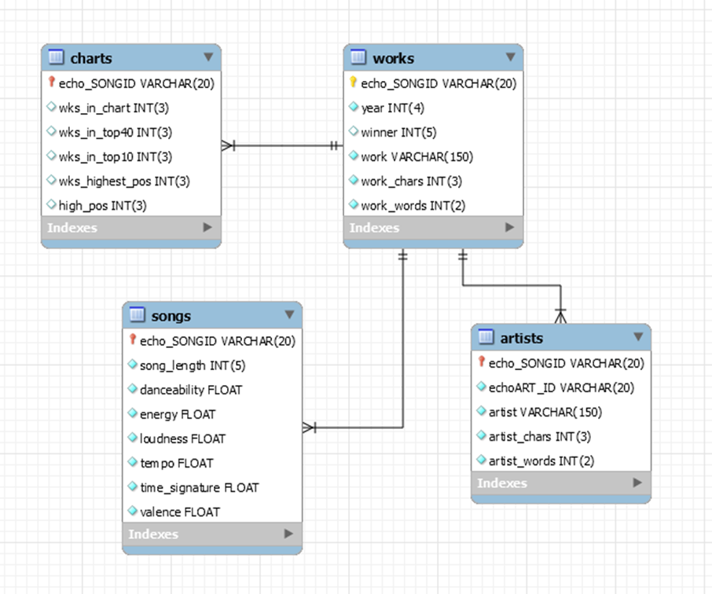

```python
from IPython.display import Image
Image(filename='Schema.png')
```

#**5. Cleaned Data - Explanatory Notes**

Below are explanatory notes that relate to each table in our schema:

**WORKS:**

1. *echo_SONGID* - This is the EchoNest unique ID that identifies the nominated record.
   2. *year* - The year that the record was nominated for the Grammy.
      3. *winner* - Indicates if the record won or not - 1 indicates winner, 0 indicates not the winner.
         4. *work* - The name of the nominated record (i.e. song title).
            5. *work_chars* - The number of characters - including white spaces and special characters - in the name of the nominated work.
               6. *work_words* - The number of words - excluding white spaces in between words - in the name of the nominated work.

**ARTISTS:**

1. *echo_SONGID* - This is the EchoNest unique ID that identifies the nominated record.
   2. *echoART_ID* - This is the EchoNest unique ID that identifies the artist/s associated with the nominated record.
      3. *artist* - The name of the artist associated with the nominated record.
         4. *artist_chars* - The number of characters - including white spaces and special characters - in the name of the artist associated with the nominated work.
            5. *artist_words* - The number of words - excluding white spaces in between words - in the name of the artist associated with the nominated work.

**CHARTS:**

1. *echo_SONGID* - This is the EchoNest unique ID that identifies the nominated record.
   2. *wks_in_chart*- How many weeks in total the record spent in the UK charts - i.e. Top 100 - from date of first entry until date of first exit. For consistency, once the record dropped out of the charts any further re-entries were not considered.
      3. *wks_in_top40*- How many weeks in total the record spent in the Top 40 in the UK charts.
         4. *wks_in_top10*- How many weeks in total the record spent in the Top 10 in the UK charts.
            5. *wks_highest_pos*- The number of total weeks that the record spent in the highest position in the UK charts that it attained. Note: these may not be consecutive weeks.
               6. *high_pos*- The highest position in the UK charts that the record attained.

Note: UK chart data was chosen as this reflects actual sales (including digital), not radio or television airtime.

**SONGS:**

1. *echo_SONGID* - This is the EchoNest unique ID that identifies the nominated record.
   2. *song_length* - The length of the record in seconds.
      3. *danceability* - The EchoNest danceability rating, defined as how easily a person could dance to a song. This is rated over the course of the entire song, using a number of different features as part of the calcuation (beat strength, tempo stability, dynamic range, overall tempo etc.). 0 equates to low danceability, 1 to maximum.
         4. *energy* - The EchoNest energy rating, or how energetic the song is. This is rated over the course of the entire song, using a number of different features as part of the calcuation (beat strength, tempo stability, dynamic range, overall tempo etc.) 0 equates to low energy, 1 to maximum.
            5. *loudness* - The EchoNest loudness calculation. This is "the overall loudness of a track in decibels (dB). Loudness values in the Analyzer are averaged across an entire track and are useful for comparing relative loudness of segments and tracks. Loudness is the quality of a sound that is the primary psychological correlate of physical strength (amplitude)."
               6. *tempo* - The EchoNest tempo calculation, being "the overall estimated tempo of a track in beats per minute (BPM). In musical terminology, tempo is the speed or pace of a given piece and derives directly from the average beat duration." The lower the figure the lower the tempo.
                  7. *time_signature* - The EchoNest time signature calculation; an estimated overall time signature of a track. The time signature (meter) is a notational convention to specify how many beats are in each bar (or measure)." These range from 3/4 to 7/8. -1 indicates dirty data. 1 indicates a difficult to classify track.
                     8. *valence* - The EchoNest valence calculation; this is a perceived happiness calculation and is based on a number of features. 0 equates to low valence, 1 to maximum.

Further information about The EchoNest attributes can be found here: http://developer.echonest.com/docs/v4/_static/AnalyzeDocumentation.pdf

**Please now open Part 2 for analysis and answers to our questions.**